# Project Management

# Creating projects in RStudio

> File: New Project

OR

> Project list (top right corner): New Project

## Project structure

I recommend

- two folders in the root of your project directory: figures-tables and data
- ProjectName.Rmd file for data visualization and data analyses

Note! RStudio project files do not play well with *Box Drive*. They do work well with *Box Sync* and *OneDrive* (I have not tested dropbox).

### Project tree structure

- MainProjectFolder/
  - data/
  - figures-tables/
  - ProjectName.Rmd
  - ProjectName.Rproj

## Data - Practice dataset

1. Go to [GitHub](https://github.com/sergioschr/R_workshop/blob/master/data/Sample-Dose-Effect-Curve.csv)
2. Right click on “Raw”
3. “Save link as” to save it in project/data folder

## Code files

Let’s create a working file for your data visualization, figures, and data analysis.

### Initial setup

1. Create Rmd file -> File:New File:R Markdown:PDF output
2. Erase body (everything below preamble)
3. Insert new R chunk (see +C “Insert” in the document top toolbar)
4. Paste the following code in the first chunk
5. Adjust chunk parameters

> {r, message=FALSE, warning=FALSE, include=FALSE}
- message=FALSE # turn off all messages
- warning=FALSE # turn off all warnings
- include=FALSE # do not show output
- find more options by googling “rstudio chunk options”
- you can adjust these parameters by using gear icon on the top right of each code chunk.

### Add project description using markdown (markdown cheat sheet can be found in RStudio under Help:Cheatsheets)

> # My ground braking experiment

> ## Overview

> This project investigates the effect of “x” on “y” in both male and female subjects.

### Import and assess data

- Insert another R chunk with the following code

```r
dataset <- read.csv("data/Sample-Dose-Effect-Curve.csv")
summary(dataset)
```

```
##     Subject      StartDate             Drug              IV.Sex
##  Min.   :8640   Length:144         Length:144         Length:144
##  1st Qu.:8646   Class :character   Class :character   Class :character
##  Median :8652   Mode  :character   Mode  :character   Mode  :character
##  Mean   :8652
##  3rd Qu.:8657
##  Max.   :8663
##   DV.Activity       IV.DOSE       DV.Response
##  Min.   :  0.0   Min.   : 0.00   Min.   :0.00000
##  1st Qu.: 82.0   1st Qu.: 5.00   1st Qu.:0.04167
##  Median :112.5   Median :15.00   Median :0.08333
##  Mean   :118.7   Mean   :20.83   Mean   :0.12674
##  3rd Qu.:152.2   3rd Qu.:30.00   3rd Qu.:0.18021
##  Max.   :324.0   Max.   :60.00   Max.   :1.00417
```

- Insert a final chunk with heading ### Data visualization

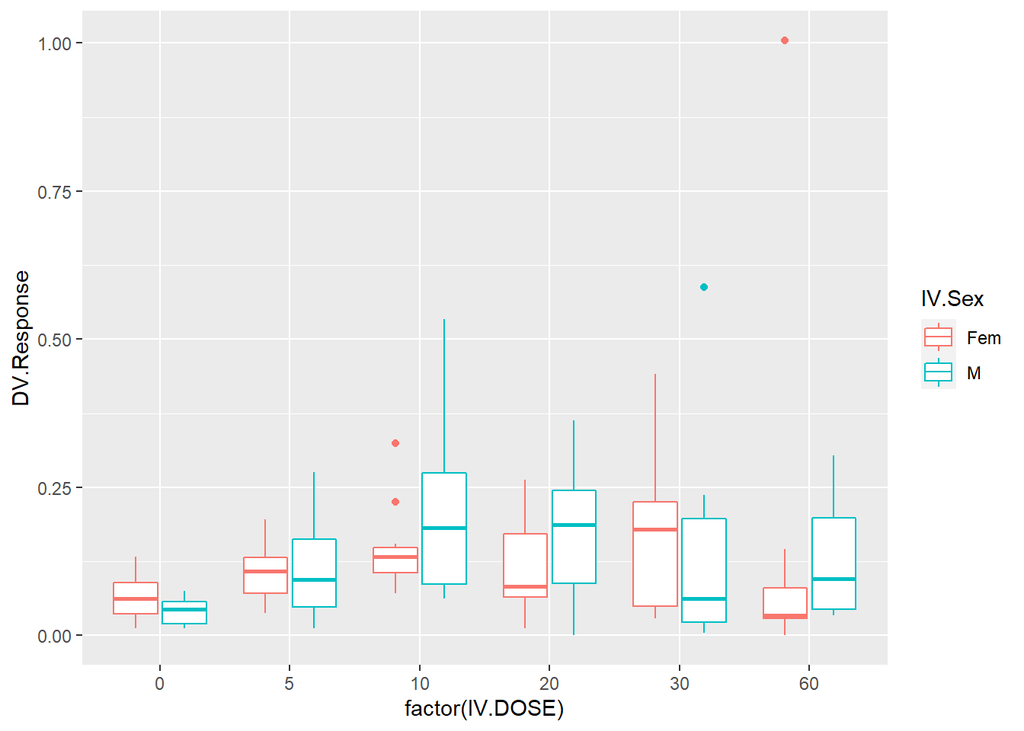

```r
ggplot(dataset, aes(x = factor(IV.DOSE), y = DV.Response, colour=IV.Sex)) +
        geom_boxplot()
```

- The plot is presented in a default ggplot configuration. This configuration is not often desirable for the publication.
- Let’s adjust some parameters to make it a bit more publication friendly.

### Convert variables to factors and rename

```r
dataset <- read.csv("data/Sample-Dose-Effect-Curve.csv")
dataset$Subject<-as.factor(dataset$Subject)
dataset$Drug<-as.factor(dataset$Drug)
dataset$Sex <-as.factor(dataset$IV.Sex )
dataset$Dose <- factor(dataset$IV.DOSE, levels=c("0","5","10", "20", "30", "60"))
summary(dataset)
```

```
##     Subject     StartDate          Drug        IV.Sex           DV.Activity
##  8640   :  6   Length:144         Bup:144   Length:144         Min.   :  0.0
##  8641   :  6   Class :character             Class :character   1st Qu.: 82.0
##  8642   :  6   Mode  :character             Mode  :character   Median :112.5
##  8643   :  6                                                   Mean   :118.7
##  8644   :  6                                                   3rd Qu.:152.2
##  8645   :  6                                                   Max.   :324.0
##  (Other):108
##     IV.DOSE       DV.Response       Sex     Dose
##  Min.   : 0.00   Min.   :0.00000   Fem:72   0 :24
##  1st Qu.: 5.00   1st Qu.:0.04167   M  :72   5 :24
##  Median :15.00   Median :0.08333            10:24
##  Mean   :20.83   Mean   :0.12674            20:24
##  3rd Qu.:30.00   3rd Qu.:0.18021            30:24
##  Max.   :60.00   Max.   :1.00417            60:24
##
```

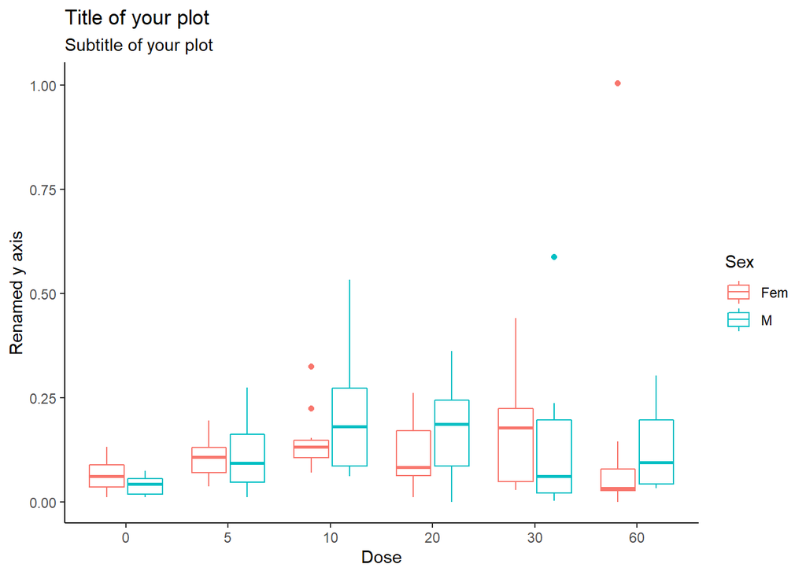

```r
# See RStudio Help->Cheatsheets for more information about data transformations, manipulations, and visualization.

# Classic theme

ggplot(dataset, aes(x = Dose, y = DV.Response, colour=Sex)) +
        geom_boxplot()+
        theme_classic()+
        labs(title = "Title of your plot", subtitle = "Subtitle of your plot", y="Renamed y axis")
```

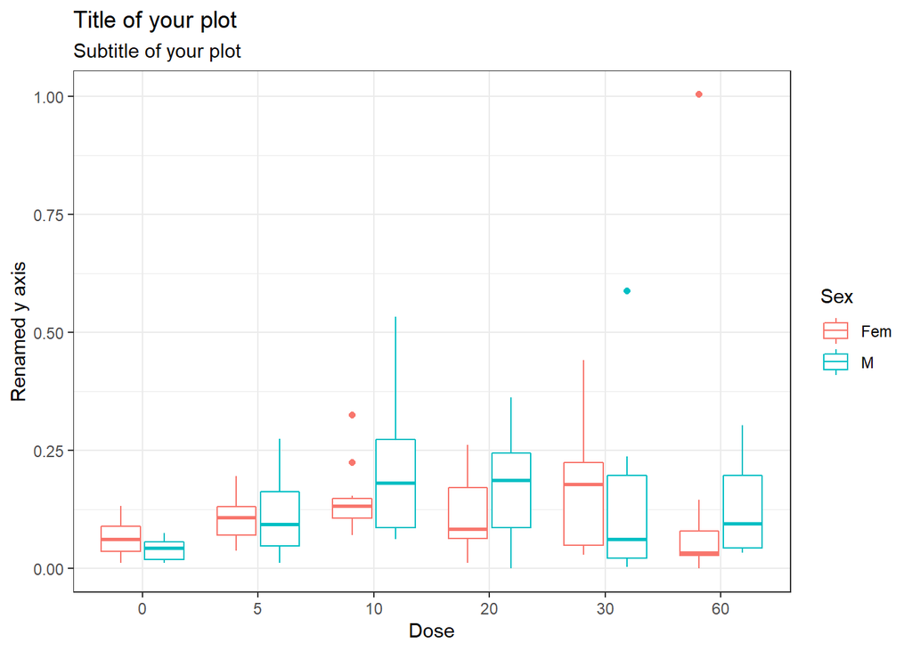

```r
# bw theme

ggplot(dataset, aes(x = Dose, y = DV.Response, colour=Sex)) +
        geom_boxplot()+
        theme_bw()+
        labs(title = "Title of your plot", subtitle = "Subtitle of your plot", y="Renamed y axis")
```

For more information on different ggplot themes see

https://ggplot2-book.org/polishing.html https://ggplot2.tidyverse.org/reference/ggtheme.html

### Create a PDF output

- Just click “Knit” on the document’s top toolbar.

### Additional learning opportunity

- place your own dataset in the data folder
- create separate Rmd data visualization file with distinct name of your dataset
- within the Rmd file create code to summarize your data and visualize your data as you like or able.
- try different themes for your plot
- try different Titles for various elements in your plot
- output Rmd to PDF file using “Knit” function
- Troubleshoot if needed by googling your problem.
- Find more information here https://ggplot2-book.org/